Skip to main content

# Pollen allergy across US states

STA220 · Data project

Author

Laure Rapp & Amir Dinari

Published

November 23, 2026

## Research question

**Is the distribution of pollen allergies unequal across US states?**

- **Hypothesis:** the proportion of patients with a pollen allergy differs between states.
- **Outcome:** pollen allergy (yes / no) for each patient.
- **Explanatory variable:** the patient’s state.

## Data and linkage

Synthetic patient data provided in the course, two datasets linked by patient id:

- `patients.csv`: one row per patient, with state and county → **6,851 patients**
- `allergies.csv`: one row per allergy diagnosis → kept only **tree and grass pollen**

Linkage: one row per patient, `pollen_allergy = TRUE` if the patient has at least one pollen diagnosis.

- **601 patients (8.8%)** have a pollen allergy, 410 of them to both tree and grass pollen.
- Data checks (`data_check`): all passed: no duplicated patients, no death before birth, every pollen record has a patient, no duplicated pollen records, no pollen diagnosis before birth or after death.

## Pollen allergy rate by state

Table 1: Patients with a pollen allergy, by state

| State | Patients | Pollen allergy | Rate |
| --- | --- | --- | --- |
| Arkansas | 1,123 | 106 | 9.4% |
| California | 1,138 | 105 | 9.2% |
| Alaska | 1,099 | 99 | 9% |
| Alabama | 1,180 | 101 | 8.6% |
| Massachusetts | 1,156 | 98 | 8.5% |
| Arizona | 1,155 | 92 | 8% |

Rates range from 8% to 9.4%.

## Map

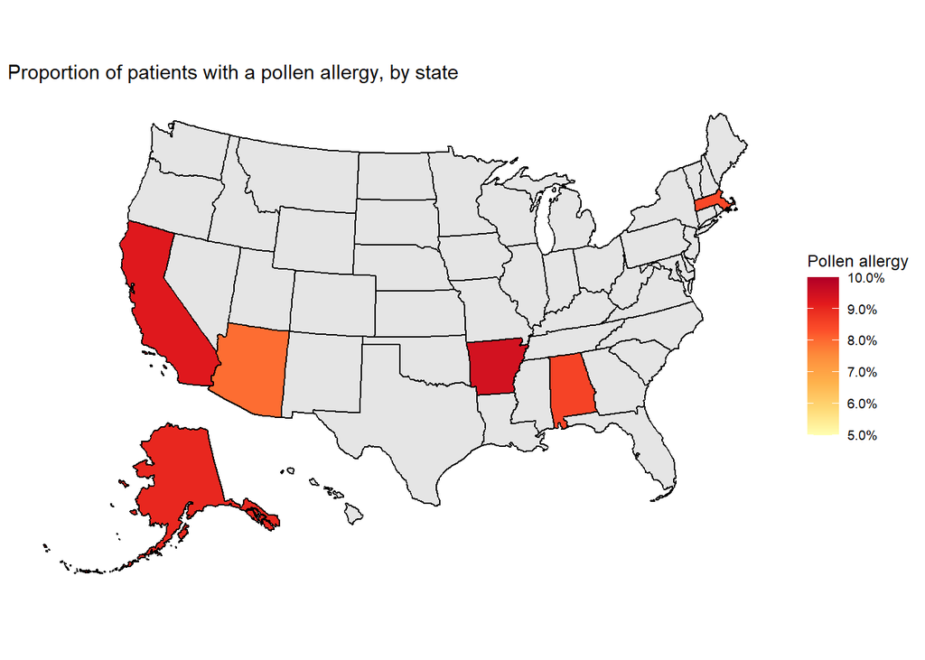

Figure 1: Proportion of patients with a pollen allergy, by state (grey: no patients in the data)

## Chi-square test

**Why:** binary outcome (allergy yes / no) and a categorical variable (state) → test of independence in a 6 × 2 table.

**Conditions** (`chi2_check`): one row per patient, no missing state, all expected counts ≥ 5 (smallest: 96.4).

**Result:** χ² = 2.13, df = 5, **p = 0.83**

**Interpretation:**

- No evidence that the proportion of pollen allergy differs between states: the hypothesis is not supported.
- A non-significant p-value does not prove that the rates are equal.
- The data are synthetic: allergies are probably simulated without any link to the state, which fits this result.

## Limitations and next steps

- **Confounding:** states may differ in age and sex structure → logistic regression `pollen_allergy ~ state + gender + age` (odds ratios with confidence intervals).
- **Size of the differences:** confidence intervals for each state’s rate, not only a p-value.
- **County level:** few patients per county → group small counties.
- **Tree vs grass pollen** analysed separately.
- **Age at first diagnosis** (`age_at_onset`): almost always 0–1 year (median 0), which is not realistic and comes from the synthetic data, so it was not analysed further.

**Reproducibility:** `{targets}` pipeline, `renv` for package versions, GitHub issues and pull requests.